# Hypothesis Testing HTML

Anton

3/3/2020

Set-up Libraries

Read/Upload Data

Examine/View Data

# Tempreture

## Wrangle Tempreture data into chunks necessary for analysis

Making subset for Mean_Tempreture date only

```r
F_T = S_D[,c(1,6)]
# View(F_T)
```

Omit all N/A from Tempreture data

```r
F_T_O = na.omit(F_T)
row.names(F_T_O) = NULL
# View(F_T_O)
```

Make two subset for test

```r
T1 = F_T_O[1:6955,]
# View(T1)
```

```r
T2 = F_T_O[6956:13910,]
# View(T2)
```

## Check for normality our Tempreture data

```r
shapiro.test(T1$Average.of.Mean_Temperature[1:5000])
```

```
##
##  Shapiro-Wilk normality test
##
## data:  T1$Average.of.Mean_Temperature[1:5000]
## W = 0.99611, p-value = 3.275e-10
```

The data is not normally distributed

Vizulize distribition

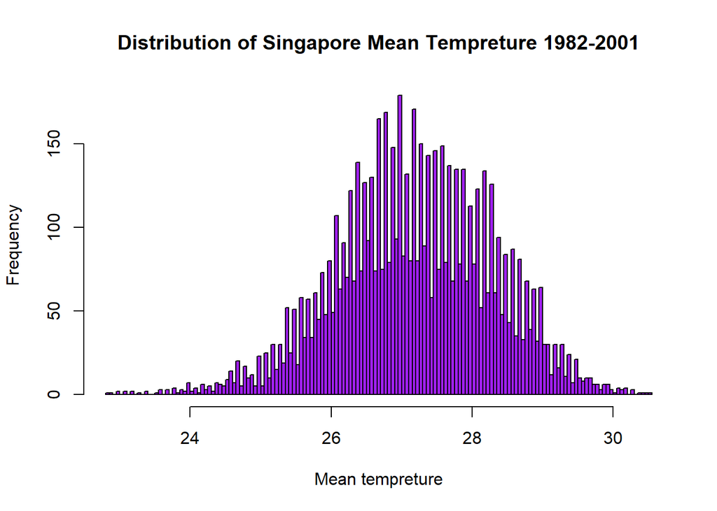

```r
hist(T1$Average.of.Mean_Temperature, breaks = 250, col = "purple", main = "Distribution of Singapore Mean Tempreture 1982-2001", xlab = "Mean tempreture")
```

```r
shapiro.test(T2$Average.of.Mean_Temperature[1:5000])
```

```
##
##  Shapiro-Wilk normality test
##
## data:  T2$Average.of.Mean_Temperature[1:5000]
## W = 0.99664, p-value = 3.477e-09
```

For the second chunk the data distributed not normal either Vizulize distribition

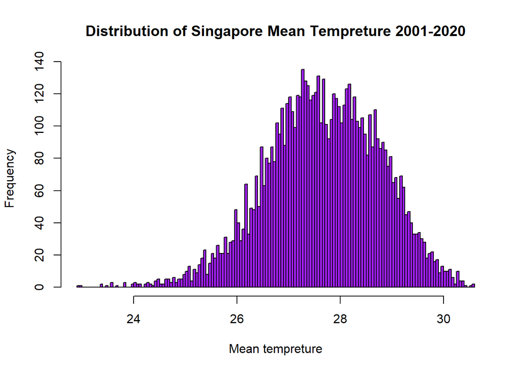

```r
hist(T2$Average.of.Mean_Temperature, breaks = 250, col = "purple", main = "Distribution of Singapore Mean Tempreture 2001-2020", xlab = "Mean tempreture")
```

## Run the non-parametrick paired test for Tempreture

Now we need to use non-parametrick test to check either or not the data have same symmetrical distribution

```r
wilcox.test(T1$Average.of.Mean_Temperature,T2$Average.of.Mean_Temperature,paired = TRUE,alternative = "two.sided")
```

```
##
##  Wilcoxon signed rank test with continuity correction
##
## data:  T1$Average.of.Mean_Temperature and T2$Average.of.Mean_Temperature
## V = 7429346, p-value < 2.2e-16
## alternative hypothesis: true location shift is not equal to 0
```

The distribution of t1 and t2 are significally different, that can account for climate change

# Rainfall

## Wrangle Data

Making subset for Mean_Rainfall date only

```r
F_R = S_D[,c(1,2)]
row.names(F_R) = NULL
# View(F_R)
```

Check for N/A

```r
count(is.na(F_R))
```

```
##   x.Full_Date x.Average.of.Daily.Rainfall.Total..mm.  freq
## 1       FALSE                                  FALSE 14641
```

Make two subset for test

```r
R1 = F_R[1:7320,]
# View(R1)
```

```r
R2 = F_R[7321:14640,]
# View(R2)
```

## Check for normality our Rain data

```r
shapiro.test(R1$Average.of.Daily.Rainfall.Total..mm.[1:5000])
```

```
##
##  Shapiro-Wilk normality test
##
## data:  R1$Average.of.Daily.Rainfall.Total..mm.[1:5000]
## W = 0.61054, p-value < 2.2e-16
```

The data is not normally distributed

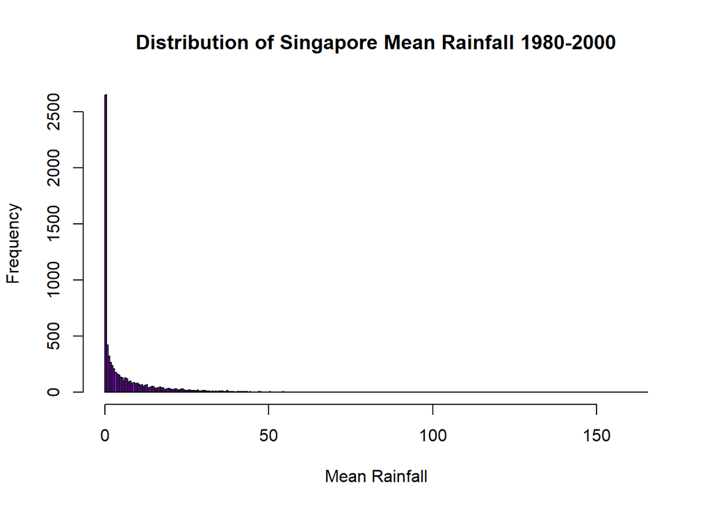

```r
hist(R1$Average.of.Daily.Rainfall.Total..mm., breaks = 250, col = "purple", main = "Distribution of Singapore Mean Rainfall 1980-2000", xlab = "Mean Rainfall")
```

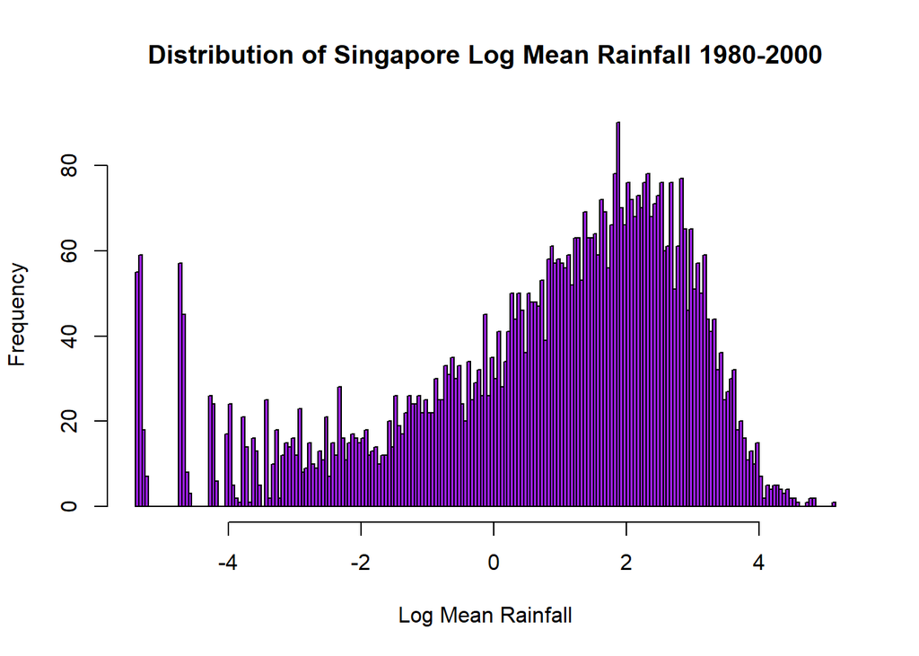

```r
hist(log(R1$Average.of.Daily.Rainfall.Total..mm.), breaks = 250, col = "purple", main = "Distribution of Singapore Log Mean Rainfall 1980-2000", xlab = "Log Mean Rainfall")
```

```r
shapiro.test(R2$Average.of.Daily.Rainfall.Total..mm.[1:5000])
```

```
##
##  Shapiro-Wilk normality test
##
## data:  R2$Average.of.Daily.Rainfall.Total..mm.[1:5000]
## W = 0.58335, p-value < 2.2e-16
```

The data is not normally distributed

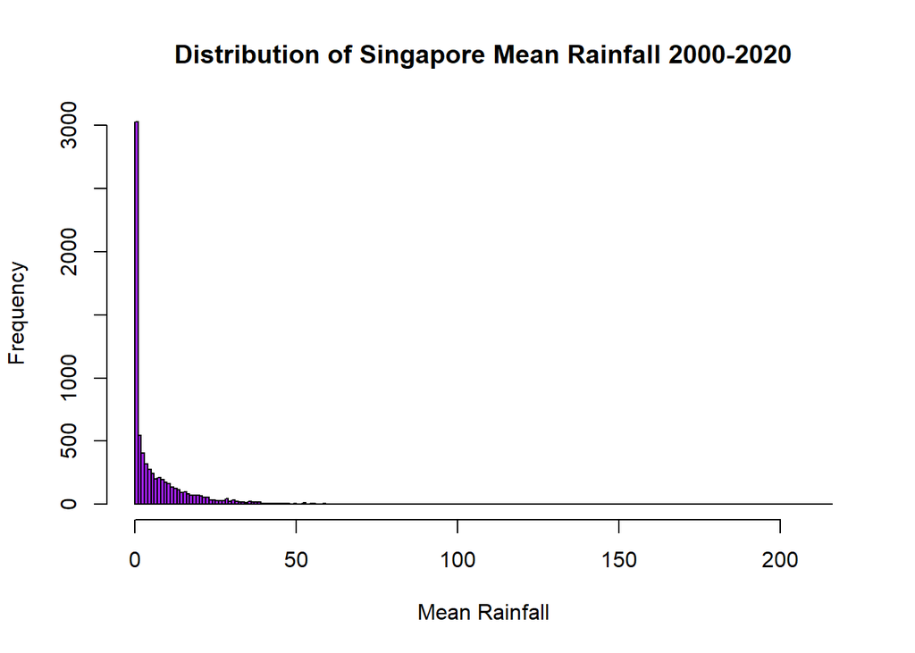

```r
hist(R2$Average.of.Daily.Rainfall.Total..mm., breaks = 250, col = "purple", main = "Distribution of Singapore Mean Rainfall 2000-2020", xlab = "Mean Rainfall")
```

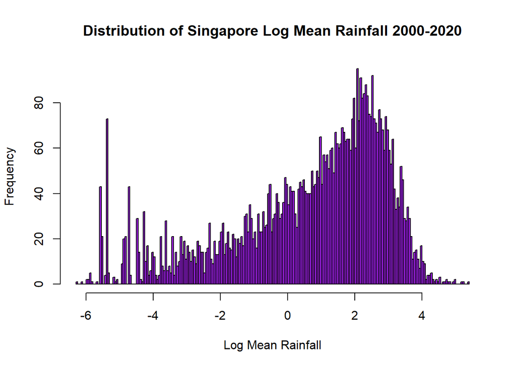

```r
hist(log(R2$Average.of.Daily.Rainfall.Total..mm.), breaks = 250, col = "purple", main = "Distribution of Singapore Log Mean Rainfall 2000-2020", xlab = "Log Mean Rainfall")
```

## Run the non-parametrick paired test for Rain

Now we need to use non-parametrick test to check either or not the data have same symmetrical distribution

```r
wilcox.test(R1$Average.of.Daily.Rainfall.Total..mm.,R2$Average.of.Daily.Rainfall.Total..mm.,paired = TRUE,alternative = "two.sided")
```

```
##
##  Wilcoxon signed rank test with continuity correction
##
## data:  R1$Average.of.Daily.Rainfall.Total..mm. and R2$Average.of.Daily.Rainfall.Total..mm.
## V = 12154752, p-value = 0.01039
## alternative hypothesis: true location shift is not equal to 0
```

for alpha 5% we reject Ho for alpha 1% accept Ho

# Wind

## Wrangle Wind data into chunks necessary for analysis

```r
F_W = S_D[,c(1,9)]
# View(F_W)
```

```r
F_W_O = na.omit(F_W)
row.names(F_W_O) = NULL
# View(F_W_O)
```

Make two subset for test

```r
W1 = F_W_O[1:7136,]
# View(W1)
```

```r
W2 = F_W_O[7137:14272,]
# View(W2)
```

## Check for normality our Wind data

```r
shapiro.test(W1$Average.of.Mean.Wind.Speed..km.h.[1:5000])
```

```
##
##  Shapiro-Wilk normality test
##
## data:  W1$Average.of.Mean.Wind.Speed..km.h.[1:5000]
## W = 0.97422, p-value < 2.2e-16
```

The data distribution is not normal

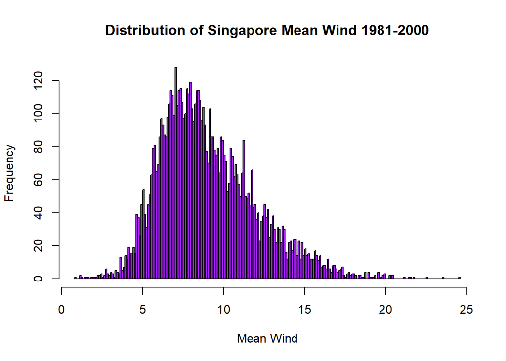

```r
hist(W1$Average.of.Mean.Wind.Speed..km.h., breaks = 300, col = "purple", main = "Distribution of Singapore Mean Wind 1981-2000", xlab = "Mean Wind")
```

```r
shapiro.test(W2$Average.of.Mean.Wind.Speed..km.h.[1:5000])
```

```
##
##  Shapiro-Wilk normality test
##
## data:  W2$Average.of.Mean.Wind.Speed..km.h.[1:5000]
## W = 0.91725, p-value < 2.2e-16
```

The Data distributed not normall

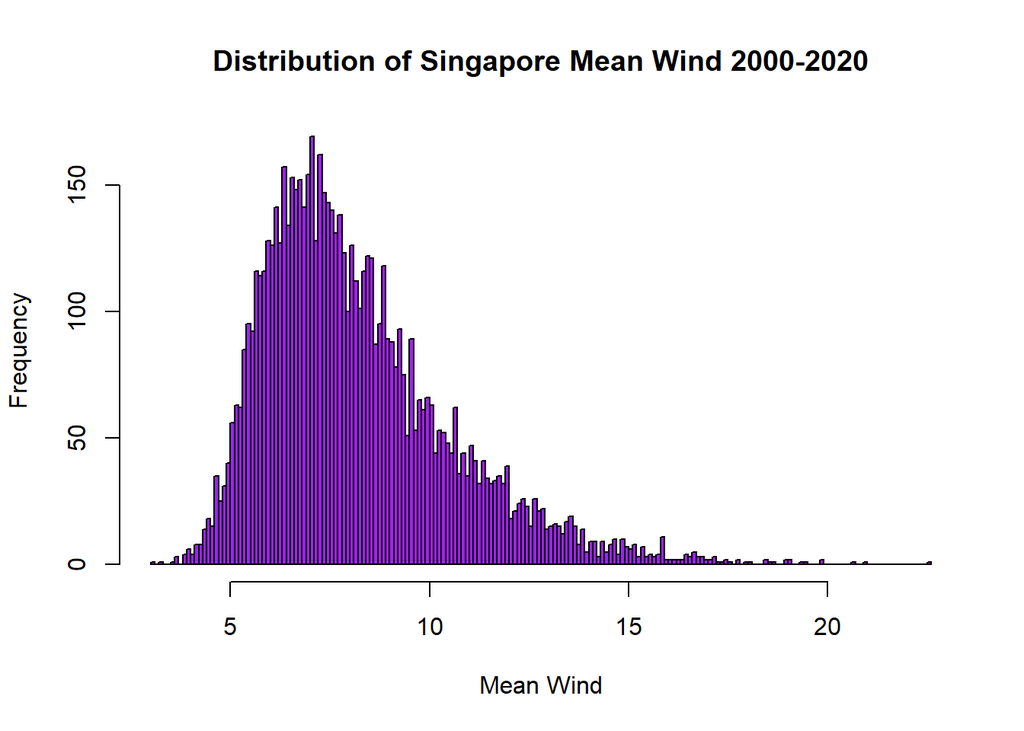

```r
hist(W2$Average.of.Mean.Wind.Speed..km.h., breaks = 250, col = "purple", main = "Distribution of Singapore Mean Wind 2000-2020", xlab = "Mean Wind")
```

Now we need to use non-parametrick test to check either or not the data have same symmetrical distribution

```r
wilcox.test(W1$Average.of.Mean.Wind.Speed..km.h.,W2$Average.of.Mean.Wind.Speed..km.h.,paired = TRUE,alternative = "two.sided")
```

```
##
##  Wilcoxon signed rank test with continuity correction
##
## data:  W1$Average.of.Mean.Wind.Speed..km.h. and W2$Average.of.Mean.Wind.Speed..km.h.
## V = 16189974, p-value < 2.2e-16
## alternative hypothesis: true location shift is not equal to 0
```

we reject Ho hence there is a change in wind